# World Plastic Waste Collection Records

Author

Faran Igani and Tyler Stoen

```r
library(tidyverse)
library(gt)
library(rvest)
library(ggplot2)
library(dplyr)
library(httr2)
library(jsonlite)
library(httr)
library(glue)
library(tidyjson)
library(ggridges)
library(scales)
library(stringdist)
library(tidytext)
```

# Data Context

```r
plastics <- readr::read_csv('https://raw.githubusercontent.com/rfordatascience/tidytuesday/main/data/2021/2021-01-26/plastics.csv')
```

This dataset comes from global plastic waste cleanup efforts organized by Break Free From Plastic, where volunteers collect and categorize plastic items found in the environment through “brand audits.” The cleaned version of the data was compiled and published by Sarah Sauvé, who documented her approach in a blog post and shared the dataset to raise awareness and support broader efforts to understand plastic pollution sources. The data were collected across multiple countries worldwide, and each row represents the outcome of a cleanup for a specific country, year (2019 or 2020), and parent company, which serves as the identified source of the plastic. The dataset records counts of different types of plastic materials, including HDPE (high-density polyethylene), LDPE (low-density polyethylene), PET (polyester), polypropylene, polystyrene, PVC, and other, with a grand total variable representing the sum of all plastic items collected. These data were gathered during organized cleanup events in which volunteers manually collected waste and categorized items by material type and branding, allowing for company-level attribution when possible.

With this dataset, we are able to look and study how plastic waste varies by geography, material type and source company across a two year period and to better understand the sources and composition of plastic pollution globally. By identifying which companies contribute most to plastic waste and how waste varies across countries and materials, the dataset supports efforts to raise awareness, inform policy, and encourage corporate accountability. The data are of particular interest because plastic pollution is a major environmental issue, and understanding its sources is a critical step toward reducing its impact.

The data was cleaned by first combining multiple country-level CSV files for each year into a single dataset using row-binding. Column types were explicitly specified to ensure consistency across files, with categorical variables stored as character and count variables as numeric. A year variable was added to distinguish observations from 2019 and 2020. The grand total variable was converted from character to numeric using a parsing function, parse_number(), to remove punctuation. Names were also converted to lowercase. The 2019 data required additional cleaning to resolve inconsistencies, including extracting country names from file names, renaming variables to match the 2020 structure, and combining duplicated columns (e.g., pp and pp_2, ps and ps_2). After merging duplicate columns, the redundant variables were removed. These steps resulted in a unified dataset with consistent structure across both years.

On top of the data cleaning done as preparation, there were some observations with missing data. In many of the cases, plastic was all classified under “other”, which provides an incorrect split of plastic types. This proves problematic for visualizing things like the split of plastic types because these plastics are almost certainly classified incorrectly. It would be misleading to replace these with zeros when investigating different plastic types, so instead we likely have to drop these rows to maintain correctness.

## Supplementary Country & Economic Data

### API 1: restcountries.com

The additional country-level data were retrieved from the REST Countries API, which is a free, community-maintained RESTful API that aggregates geographic and demographic information for over 250 countries from various public sources. The data represent country-level attributes, so the observational unit is a country, with variables such as region, subregion, United Nations membership status, population density, and geographic coordinates. Unlike the plastics dataset, these data are not tied to a specific year; instead, they reflect the current state of country metadata at the time of access, as the API is continuously updated. The data were collected programmatically by sending an HTTP request to the API endpoint using the httr package in R, and the returned JSON data were parsed and converted into a tidy format using jsonlite. We chose to include this dataset to provide additional geographic and geo-political context for the countries in the plastic pollution data, allowing us to group, compare, and visualize patterns in plastic waste collection across regions and levels of development.

```r
base_url <- "https://restcountries.com/v4/"

restcountries <- GET(glue("{base_url}all?fields=name,continents,region,subregion,unMember,gini,density,geolocation"))

restcountries

restcountries_tidy <- restcountries %>%
  content(as = "text") %>%
  fromJSON(flatten = TRUE) %>%
  as_tibble()
```

```r
library(stringi)

normalize_name <- function(x) {
  x %>%
    stri_trans_general("Latin-ASCII") %>%
    str_to_lower() %>%
    str_remove_all("[^a-z ]") %>%
    str_trim() %>%
    str_squish()
}

plastics_clean <- plastics %>%
  filter(country != "EMPTY") %>%
  mutate(
    country = case_when(
      country == "Korea" ~ "South Korea",
      country == "Taiwan_ Republic of China (ROC)" ~ "Taiwan",
      country == "United Kingdom of Great Britain & Northern Ireland" ~
        "United Kingdom",
      TRUE ~ country
    )
  ) %>%
  mutate(country_key = normalize_name(country))

restcountries_clean <- restcountries_tidy %>%
  dplyr::select(name.common, name.official, region, subregion,
         density, unMember, geolocation.latitude,
         geolocation.longitude) %>%
  mutate(common_key = recode(
    normalize_name(name.common),
    "ivory coast" = "cote divoire"
    ),
         official_key = normalize_name(name.official))


# Different name types, try both

joined <- plastics_clean %>%
  left_join(
    restcountries_clean %>% dplyr::select(-official_key),
    by = c("country_key" = "common_key")
  )

matched <- joined %>% filter(!is.na(region))
unmatched <- joined %>% filter(is.na(region)) %>%
  dplyr::select(names(plastics_clean))

refilled <- unmatched %>%
  left_join(
    restcountries_clean %>% dplyr::select(-common_key),
    by = c("country_key" = "official_key")
  )

joined1 <- bind_rows(matched, refilled)
```

```r
## Fuzzy matching for parent companies using stringdist

noise_words <- c(
  "\\bthe\\b",
  "\\binc\\.?\\b",
  "\\bco\\.?\\b",
  "\\bltd\\.?\\b",
  "\\bcorp\\.?\\b",
  "\\bcompany\\b",
  "\\bcompanies\\b",
  "\\bgroup\\b",       # "Nestlé Group" -> "nestlé"
  "\\bholdings\\.?\\b",
  "\\bllc\\.?\\b",
  "\\bplc\\.?\\b",
  "\\bgmbh\\b",        # common German suffix
  "\\bsa\\b",          # common in Latin America/Europe
  "\\bsrl\\b"
)

normalize_company <- function(x) {
  x %>%
    str_to_lower() %>%
    str_remove_all(paste(noise_words, collapse = "|")) %>%
    str_remove_all("[^a-z0-9 ]") %>%
    str_squish()
}

resolve_typos <- function(names, threshold = 0.1) {
  dist_matrix <- stringdistmatrix(names, names, method = "jw")
  diag(dist_matrix) <- Inf

  canonical <- names

  for (i in seq_along(names)) {
    best_dist <- min(dist_matrix[i, ])
    if (best_dist < threshold) {
      best_match <- which.min(dist_matrix[i, ])
      canonical[i] <- min(names[i], names[best_match])
    }
  }

  tibble(normalized = names, canonical = str_to_title(canonical))
}

companies_raw <- unique(joined$parent_company)

name_map <- tibble(original = companies_raw) %>%
  mutate(normalized = normalize_company(original)) %>%
  left_join(
    resolve_typos(unique(.$normalized)),  # fuzzy match on normalized names only
    by = "normalized"
  )

canonical_labels <- name_map %>%
  count(canonical, original) %>%          # count how often each original appears
  slice_max(n, by = canonical, n = 1, with_ties = FALSE) %>% # pick the most frequent per canonical
  dplyr::select(canonical, display_name = original)

joined <- joined1 %>%
  left_join(name_map %>% dplyr::select(original, canonical),
            by = c("parent_company" = "original")) %>%
  left_join(canonical_labels, by = "canonical") %>%
  mutate(parent_company = display_name) %>%
  dplyr::select(-display_name, -canonical) %>%
  mutate(country = str_to_title(country_key))
```

### API 2: worldbank

We retrieved total population data and GDP data (in current U.S. dollars) for the years corresponding to collection years in the plastics dataset (2019 and 2020) from the World Bank’s World Development Indicators (WDI), a comprehensive collection of country-level development statistics compiled from official international sources. The data were published by the World Bank, with GDP and population estimates produced by World Bank country economists using information from national statistical agencies, the OECD, and other official country sources. The observational unit for this dataset is a country–year combination, matching the structure of the plastics data. The data correspond specifically to the years 2019 and 2020, aligning with the time frame of the cleanup records. These data were collected programmatically by sending requests to the World Bank Indicators REST API, and the returned JSON data were parsed and converted into a tidy format. We chose to include this dataset because it provides important economic context for the countries where plastic waste was collected, allowing us to explore how factors such as GDP and population relate to patterns in plastic waste across countries.

```r
base_url <- "https://api.worldbank.org/v2/country/all/indicator/"

pop_code <- "SP.POP.TOTL"
gdp_code <- "NY.GDP.MKTP.CD"

pop_url <- str_c(base_url, pop_code, "?format=json&per_page=20000")
gdp_url <- str_c(base_url, gdp_code, "?format=json&per_page=20000")

pop_raw <- GET(pop_url) %>%
  content(as = "text") %>%
  fromJSON(flatten = TRUE) %>%
  pluck(2) %>%
  as_tibble() %>%
  dplyr::select(
    country.value,
    year = date,
    population = value
  ) %>%
  mutate(year = as.numeric(year)) %>%
  filter(year %in% c(2019, 2020))

gdp_raw <- GET(gdp_url) %>%
  content(as = "text") %>%
  fromJSON(flatten = TRUE) %>%
  pluck(2) %>%
  as_tibble() %>%
  dplyr::select(
    country.value,
    year = date,
    gdp = value
  ) %>%
  mutate(year = as.numeric(year)) %>%
  filter(year %in% c(2019, 2020))

pop_and_gdp_raw <- inner_join(pop_raw, gdp_raw, by = c("country.value", "year")) %>%
  mutate(country.value = recode(
           country.value,
          "Turkiye" = "Turkey",
          "Hong Kong SAR, China" = "Hong Kong",
          "Viet Nam" = "Vietnam",
          "Korea, Rep." = "South Korea",
          "United States" = "United States of America"
          ),
         country_code = normalize_name(country.value))

joined_all <- joined %>%
  left_join(pop_and_gdp_raw, by = c("country_key" = "country_code", "year")) %>%
  mutate(
    gdppercapita = gdp / population
  )
```

# Research Questions

- What are the characteristics of recorded plastic waste, specifically in terms of the companies most responsible for the waste and the plastic types most commonly collected?
- How does country geography and economic status effect their amount of recorded plastic waste? Do more developed countries in terms of GDP and population tend to have more or less recorded waste?

# Findings

## What Types of Plastic Are Collected, and Who Produces Them?

To investigate the characteristics of recorded plastic waste, we examine two aspects: the companies responsible for the waste and the types of plastic collected.

### Figure 1: Plastic Type Distribution

In this dataset, plastics were categorized into eight types — High-Density Polyethylene (HDPE), Low-Density Polyethylene (LDPE), Other (O), Polyethylene Terephthalate (PET), Polypropylene (PP), Polystyrene (PS), Polyvinyl Chloride (PVC), and Empty (items with no plastic type recorded). Figure 1 displays each plastic type as a proportion of total plastic collected, comparing 2019 and 2020.

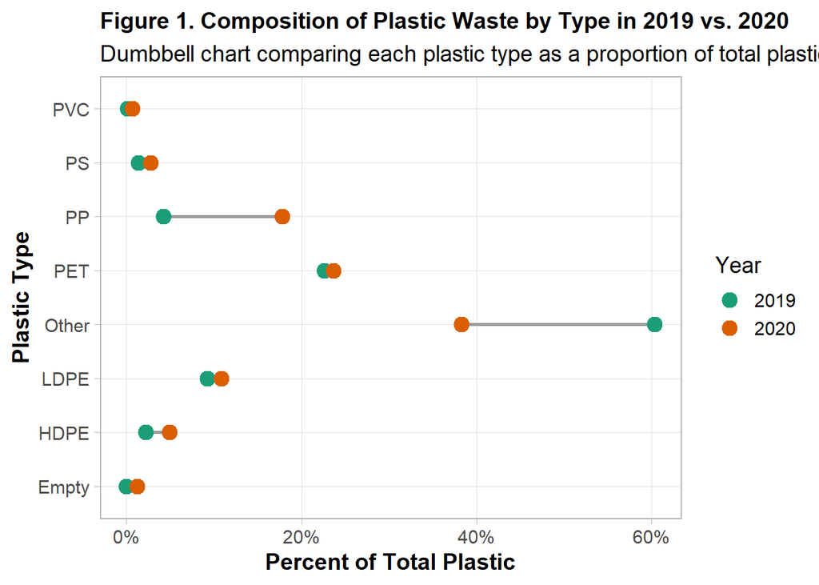

```r
calc_prop <- function(var, data) {
  data %>%
    filter(grand_total > 0, parent_company != "Grand Total") %>%
    group_by(year) %>%
    summarise(
      prop = sum(.data[[var]], na.rm = TRUE) / sum(grand_total, na.rm = TRUE),
      .groups = "drop"
    ) %>%
    mutate(plastic_type = var)
}

plastic_vars <- c("empty", "hdpe", "ldpe", "o", "pet", "pp", "ps", "pvc")

table3_year <- map_dfr(plastic_vars, calc_prop, data = plastics) %>%
  mutate(
    plastic_type = recode(
      plastic_type,
      empty = "Empty",
      hdpe = "HDPE",
      ldpe = "LDPE",
      o = "Other",
      pet = "PET",
      pp = "PP",
      ps = "PS",
      pvc = "PVC"
    )
  ) %>%
  pivot_wider(
    names_from = plastic_type,
    values_from = prop
  ) %>%
  rename(Year = year)

table3_long <- table3_year %>%
  pivot_longer(
    cols = -Year,
    names_to = "plastic_type",
    values_to = "prop"
  )

ggplot(table3_long, aes(x = prop, y = plastic_type)) +
  geom_line(aes(group = plastic_type), color = "grey60", linewidth = 1) +  # connecting line between years
  geom_point(aes(color = factor(Year)), size = 4) +
  scale_x_continuous(labels = percent_format()) +
  scale_color_brewer(palette = "Dark2", name = "Year") +
  labs(
    title = "Figure 1. Composition of Plastic Waste by Type in 2019 vs. 2020",
    subtitle = "Dumbbell chart comparing each plastic type as a proportion of total plastic collected",
    x = "Percent of Total Plastic",
    y = "Plastic Type"
  ) +
  theme_light(base_size = 14) +
  theme(
    plot.title = element_text(face = "bold", size = 14),
    axis.title = element_text(face = "bold"),
    panel.grid.minor = element_blank()
  )
```

Figure 1 displays each plastic type as a proportion of total plastic collected, comparing 2019 and 2020. The most striking pattern is the dominance of the “Other” category, which accounts for approximately 60% of all recorded plastic in 2019. Notably, this percentage dips to below 40% in 2020. A shift of this magnitude in a year time frame is unlikely to reflect a true change in plastic distribution, and more plausibly reflects improved plastic type recording between years. Among the named types, PET and PP represent the largest shares, which is consistent with their widespread use in beverage bottles and food packaging. Other plastic types such as PVC and Polystyrene make up a very small percentage of collected waste, possibly due to their niche use and typically larger size. Overall, these results indicate that plastic waste is not evenly distributed across types, but instead concentrated among a few categories, highlighting important patterns in material waste distribution.

### Table 1: Dominant Plastic Type Table by Country in 2020

As seen in Figure 1, the proportion of plastic recorded under the “Other” category dropped substantially in 2020, suggesting more consistent and complete plastic type classification compared to 2019. For this reason, 2020 data is used for the country-level breakdown in Table 1, as it better reflects the true distribution of plastic types across named categories.

```r
plastic_types <- c("hdpe", "ldpe", "o", "pet", "pp", "ps", "pvc")

dominant_plastic <- function(ctry) {

  ctry_norm <- normalize_name(ctry)

  df <- joined_all %>%
    filter(country_key == ctry_norm) %>%
    filter(year == 2020) %>%
    summarise(across(all_of(plastic_types), ~ sum(.x, na.rm = TRUE)))

  total <- sum(df, na.rm = TRUE)

  tibble(
    country       = str_to_title(ctry_norm),
    dominant_type = plastic_types[which.max(df)],
    dominant_n    = max(df),
    dominant_prop = dominant_n/total
  )
}

top_countries <- joined_all %>%
  filter(year == 2020) %>%
  group_by(country_key) %>%
  summarise(total = sum(grand_total, na.rm = TRUE)) %>%
  slice_max(total, n = 10) %>%
  pull(country_key)

top_countries %>%
  map(dominant_plastic) %>%
  bind_rows() %>%
  arrange(desc(dominant_n)) %>%
  mutate(dominant_type = dominant_type %>%
           recode_values(
             "o" ~ "Other",
             "ldpe" ~ "Low-Density Polyethylene",
             "hdpe" ~ "High-Density Polyethylene",
             "pet" ~ "Polyester",
             "pp" ~ "Polypropylene",
             "ps" ~ "Polystyrene",
             "pvc" ~ "PVC")
  ) %>%
  gt() %>%
  tab_header(
    title = md("**Table 1. Dominant Plastic Type for Top 10 Countries in Total Recorded Waste (2020)**")
    ) %>%
  tab_source_note(
    source_note = "Most commonly recorded plastic type for the countries producing the largest amount of plastic waste in 2020."
  ) %>%
  cols_label(
    country       = "Country",
    dominant_type = "Dominant Plastic Type",
    dominant_n    = "Dominant Plastic Count",
    dominant_prop = "Percent of Country Total"
  ) %>%
  tab_style(
    style     = cell_text(weight = "bold"),
    locations = cells_column_labels()
  ) %>%
  fmt_number(columns = dominant_n, decimals = 0) %>%
  fmt_percent(columns = dominant_prop, decimals = 2) %>%
  data_color(
    columns = dominant_prop,
    method  = "numeric",
    palette = c("#fff5eb", "#d94701")
  )
```

**Table 1. Dominant Plastic Type for Top 10 Countries in Total Recorded Waste (2020)**

| Country | Dominant Plastic Type | Dominant Plastic Count | Percent of Country Total |
| --- | --- | --- | --- |
| Switzerland | Other | 45,612 | 91.34% |
| Philippines | Polypropylene | 41,987 | 76.56% |
| Nigeria | Polyester | 27,390 | 43.52% |
| Togo | Other | 11,233 | 93.66% |
| Ghana | Polyester | 8,272 | 94.18% |
| Kenya | Polyester | 7,797 | 88.04% |
| India | Other | 7,369 | 43.47% |
| Vietnam | Other | 4,779 | 54.95% |
| United States Of America | Other | 4,485 | 33.18% |
| Indonesia | Polypropylene | 2,912 | 28.69% |

Most commonly recorded plastic type for the countries producing the largest amount of plastic waste in 2020.

Plastic waste at the country level is often dominated by a single plastic type, with many of the top countries in recorded waste showing very high concentration in one category. Countries where “Other” is the dominant category, such as Switzerland and the United States, are harder to draw conclusions from, as “Other” likely includes many different plastic types that were not individually classified. In contrast, countries where a specific named type dominates are more informative. For example, Ghana and Kenya show over 88% of their recorded waste classified as Polyester, and the Philippines and Indonesia show Polypropylene as the dominant type with 77% and 29% respectively. These specific classifications suggest meaningful differences in the types of plastic products entering the waste stream across countries, potentially reflecting differences in local consumer goods and local production.

### Table 2: Top Parent Company by Country

As previously noted, waste was also tracked by parent company where possible. Identifying the companies behind recorded plastic waste is important not just for understanding composition, but for accountability. Knowing which corporations contribute most to plastic pollution in specific countries could help regulate and corporate waste efforts. Table 2 below shows the top contributing company by country, measured as a percentage of that country’s total recorded waste.

```r
top_company_by_country <- function(ctry) {

  ctry_norm <- normalize_name(ctry)

  country_companies <- joined_all %>%
    filter(country_key == ctry_norm) %>%
    mutate(parent_company = str_squish(parent_company)) %>%
    filter(!is.na(parent_company),
           !(parent_company %in% c("Grand Total", "null", "Unbranded", "Assorted", "NULL")))

  country_total <- country_companies %>%
  summarise(total = sum(grand_total, na.rm = TRUE)) %>%
  pull(total)

  country_companies %>%
    group_by(parent_company) %>%
    summarise(total = sum(grand_total, na.rm = TRUE)) %>%
    slice_max(total, n = 1) %>%
    mutate(country = str_to_title(ctry_norm),
           percent = total / country_total)
}

joined_all %>%
  distinct(country_key) %>%
  pull(country_key) %>%
  map(top_company_by_country) %>%
  list_rbind() %>%
  filter(!is.nan(percent)) %>%
  dplyr::select(country, parent_company, percent) %>%
  arrange(desc(percent)) %>%
  gt() %>%
  cols_label(
    country        = "Country",
    parent_company = "Parent Company",
    percent        = "Percent"
  ) %>%
  tab_style(
    style = cell_text(weight = "bold"),
    locations = cells_column_labels()
  ) %>%
  fmt_percent(columns = percent, decimals = 2) %>%
  tab_header(
    title = md("**Table 2. Company's Contributing
                 the Most Recorded Waste by Country**")
  ) %>%
  tab_source_note(
    source_note = "Parent company with the largest number of recorded waste items in each country."
  ) %>%
  opt_interactive(
    use_pagination = TRUE,
    page_size_default = 10    # number of rows shown at once
  )
```

**Table 2. Company’s Contributing the Most Recorded Waste by Country**

| Country | Parent Company | Percent |
| --- | --- | --- |
| Cote Divoire | AWA | 1 |
| Cyprus | AGROS WATER | 1 |
| Maldives | Nestle | 1 |
| Taiwan | Imperial Brands | 1 |
| Honduras | PepsiCo | 1 |
| Benin | Pure Water, Inc. | 0.984603237268062 |
| Turkey | Nestle | 0.97752808988764 |
| Togo | Philip Morris International | 0.951199338296112 |
| United Arab Emirates | Mai Dubai | 0.916666666666667 |
| El Salvador | The Coca-Cola Company | 0.830508474576271 |

[output cut: 53 more lines]

Parent company with the largest number of recorded waste items in each country.

Plastic waste at the country level is often dominated by a single parent company, with several countries showing extremely high concentration. In multiple cases, including Côte d’Ivoire, Cyprus, and Honduras, one company accounts for 100% of the recorded waste, however this likely reflects limited collection coverage. Despite this, other countries still show strong dominance with shares exceeding 80% such as South Africa. These patterns suggest that plastic waste generation is not evenly distributed across producers, but instead concentrated among a small number of companies within each country. For example, The Coca-Cola Company appears as the top contributor in the largest number of countries, spanning regions including Europe, Asia, Africa, and the Americas, reinforcing its status as one of the most frequently identified sources of plastic waste globally.

### Figure 2: Top Parent Company by Continent Graph

While Table 2 highlighted the dominant company within each individual country, Figure 2 broadens this view by aggregating recorded plastic waste to the regional level, showing the top 5 contributing companies across Africa, the Americas, Asia, and Europe. This allows us to identify which companies not only dominate locally but maintain a significant plastic footprint across entire regions.

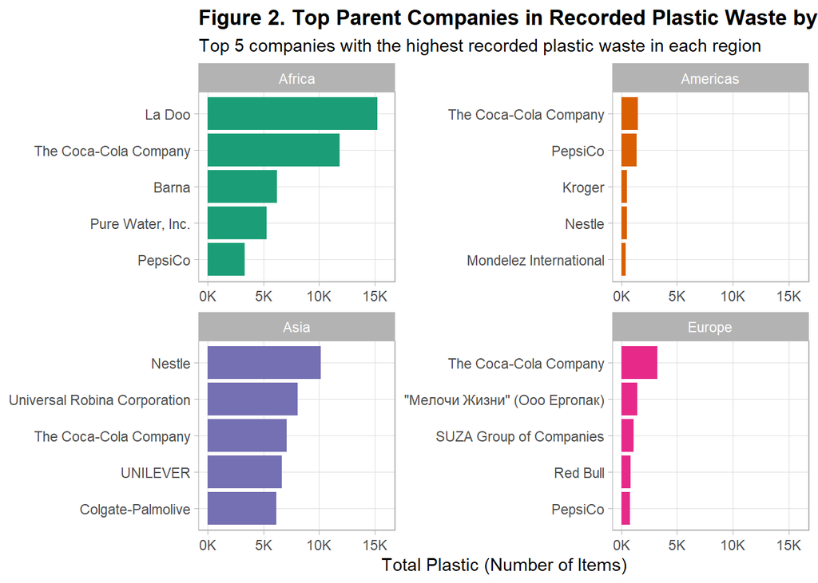

Bar chart showing the parent companies with the highest total recorded plastic waste, grouped by region.

```r
top_companies_region <- joined_all %>%
  filter(
    !is.na(parent_company),
    !is.na(region),
    region != "Oceania",
    !(parent_company %in% c("Grand Total", "null", "Unbranded", "Assorted", "NULL"))
  ) %>%
  group_by(region, parent_company) %>%
  summarise(
    total_plastic = sum(grand_total, na.rm = TRUE),
    .groups = "drop"
  ) %>%
  group_by(region) %>%
  slice_max(order_by = total_plastic, n = 5, with_ties = FALSE) %>%
  ungroup() %>%
  mutate(
    company_ordered = reorder_within(parent_company, total_plastic, region)
  )

ggplot(top_companies_region,
       aes(x = total_plastic, y = company_ordered, fill = region)) +
  geom_col(show.legend = FALSE) +
  facet_wrap(~ region, scales = "free") +
  scale_y_reordered() +
  scale_x_continuous(
  limits = c(0, 16000), # take out to not scale
  breaks = seq(0, 15000, by = 5000), # take out
  labels = label_number(scale = 1e-3, suffix = "K")
) +
  labs(
    title = "Figure 2. Top Parent Companies in Recorded Plastic Waste by Region",
    subtitle = "Top 5 companies with the highest recorded plastic waste in each region",
    x = "Total Plastic (Number of Items)",
    y = NULL
  ) +
  scale_fill_brewer(palette = "Dark2") +
  theme_light() +
  theme(
    plot.title = element_text(face = "bold"),
    plot.subtitle = element_text(size = 11),
    panel.grid.minor = element_blank()
  )
```

The distribution of plastic waste across companies shows strong concentration within regions, with only a handful of firms accounting for the majority of recorded waste. While global corporations such as The Coca-Cola Company, Nestlé, and PepsiCo appear across multiple regions, regional companies also play a dominant role, particularly in Africa and Asia. This indicates that plastic waste patterns are driven by both international supply chains and localized production and consumption, reinforcing the importance of targeting key companies in efforts to reduce waste.

## Does Geography or Wealth Predict Recorded Plastic Waste?

Our second research question, investigates the effect of country location and both social and economic development on the amount of recorded plastic.

### Figure 3: Plastic Waste per Capita Across World Regions

To address the geographic dimension of our research question, Figure 3 examines how recorded plastic waste per person is distributed across world regions. Rather than comparing raw totals, which can be heavily influenced by country size and collection scale, normalizing by population allows for a fairer cross-country comparison of waste intensity.

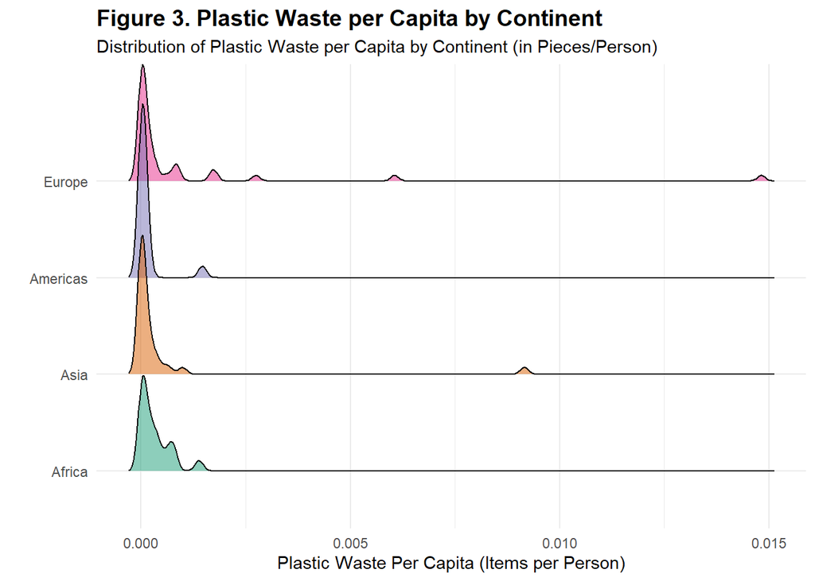

Density ridge plot showing the distribution of pieces of plastic collected per capita across regions. Each ridge represents the distribution of country-level plastic totals per capita within a region.

```r
vis_1.5 <- joined_all %>%
  filter(!is.na(region), region != "Oceania") %>%
  group_by(country, region, population) %>%
  summarize(
    total = sum(grand_total, na.rm = TRUE), .groups = "drop"
  ) %>%
  mutate(
    region = fct_reorder(region, total, .desc = TRUE),
    waste_per_capita = total/population
  ) %>%
  ggplot(aes(x=waste_per_capita, y=region, fill=region)) +
  geom_density_ridges(alpha = 0.5, height = 0.1, position = "identity") +
  labs(
    title = "Figure 3. Plastic Waste per Capita by Continent",
    subtitle = "Distribution of Plastic Waste per Capita by Continent (in Pieces/Person)",
    x= "Plastic Waste Per Capita (Items per Person)",
    y= ""
  ) +
  scale_fill_brewer(palette = "Dark2") +
  theme_minimal() +
  theme(legend.position = "none",
        plot.title = element_text(face = "bold", size = 14))

vis_1.5
```

Geographic patterns show clear differences in plastic waste across regions. As seen in Figure 3, continents across the board seem to have waste per capita distributions peaked at very similar levels. Countries in Europe seem to have a few outlier countries, including some extreme outliers, having extremely high plastic waste per capita. Africa and much of Asia are less concentrated at lower levels, having more variability and skewed per capita recorded waste distributions. Finally, America has the most symmetric distribution, with low average waste per capita and few outliers.

### Table 3: Top 20 Countries by Recorded Plastic Per Person Table

To investigate the extreme outliers outlined by Figure 3, Table 3 normalizes recorded plastic waste by population, expressing each country’s total as plastic items collected per person.

```r
joined_all %>%
  group_by(country) %>%
  summarise(
    total_plastic = sum(grand_total, na.rm = TRUE),
    population = mean(population, na.rm = TRUE),
    plastic_per_person = total_plastic / population,
    .groups = "drop"
  ) %>%
  arrange(desc(plastic_per_person))%>%
  slice_head(n = 20) %>%
  gt() %>%
  cols_label(
    country = md("**Country**"),
    total_plastic = md("**Total Plastic**"),
    population = md("**Population**"),
    plastic_per_person = md("**Plastic per Person**")
  ) %>%
  fmt_number(
    columns = c(total_plastic, population),
    decimals = 0
  ) %>%
  fmt_number(
    columns = plastic_per_person,
    decimals = 5
  ) %>%
  tab_header(
    title = md("**Table 3. Top 20 Countries by Plastic Contributed per Person**")
  ) %>%
  tab_source_note(
    source_note = "Plastic per person was calculated as total plastic collected divided by population."
  ) %>%
  opt_interactive(
    use_pagination = TRUE,
    page_size_default = 10    # number of rows shown at once
  )
```

**Table 3. Top 20 Countries by Plastic Contributed per Person**

| <span data-qmd-base64="KipDb3VudHJ5Kio="><span class='gt_from_md'><strong>Country</strong></span></span> | <span data-qmd-base64="KipUb3RhbCBQbGFzdGljKio="><span class='gt_from_md'><strong>Total Plastic</strong></span></span> | <span data-qmd-base64="KipQb3B1bGF0aW9uKio="><span class='gt_from_md'><strong>Population</strong></span></span> | <span data-qmd-base64="KipQbGFzdGljIHBlciBQZXJzb24qKg=="><span class='gt_from_md'><strong>Plastic per Person</strong></span></span> |
| --- | --- | --- | --- |
| Montenegro | 10351 | 626678.909090909 | 0.0165172305144522 |
| Bhutan | 7000 | 764824 | 0.00915243245504848 |
| Switzerland | 67279 | 8592224.55277778 | 0.00783021900635143 |
| Latvia | 5786 | 1909167.67156863 | 0.00303064004600814 |
| Ecuador | 25703 | 17377176.4754098 | 0.00147912407037886 |
| Togo | 11994 | 8669720 | 0.00138343568189053 |
| Philippines | 129216 | 110989026.826715 | 0.00116422320020647 |
| Slovenia | 2427 | 2092608.82524272 | 0.00115979631296762 |
| Nigeria | 224393 | 211678719.229318 | 0.00106006404808652 |
| Portugal | 10414 | 10290025.7826087 | 0.00101204799871355 |

[output cut: 10 more lines]

Plastic per person was calculated as total plastic collected divided by population.

### Table 4: Do Wealthier Countries Record More Plastic Waste per Person?

```r
# GDP per capita income brackets
income_breaks <- c(0, 10000, 20000, 40000, Inf)
income_labels <- c("Low (<$10K)", "Lower-Middle ($10K-$20K)",
                   "Upper-Middle ($20K-$40K)", "High (>$40K)")

country_level <- joined_all %>%
  filter(!(parent_company %in% c("Grand Total", "null", "Unbranded", "Assorted", "NULL"))) %>%
  group_by(country, region, gdppercapita, population) %>%
  summarise(total_plastic = sum(grand_total, na.rm = TRUE), .groups = "drop") %>%
  mutate(
    plastic_per_capita = total_plastic / population,
    income_group = cut(gdppercapita, breaks = income_breaks, labels = income_labels)
  )

# Custom function: summary stats for one income group
summarise_income_group <- function(group_name) {
  country_level %>%
    filter(income_group == group_name) %>%
    summarise(
      income_group        = group_name,
      n_countries         = n(),
      avg_gdp_per_capita  = mean(gdppercapita, na.rm = TRUE),
      avg_plastic_per_capita = mean(plastic_per_capita, na.rm = TRUE),
      median_plastic_per_capita = median(plastic_per_capita, na.rm = TRUE),
      total_plastic       = sum(total_plastic, na.rm = TRUE)
    )
}

income_summary <- income_labels %>%
  map(summarise_income_group) %>%
  list_rbind()

income_summary %>%
  gt() %>%
  cols_label(
    income_group = md("**Income Group**"),
    n_countries = md("**Countries**"),
    avg_gdp_per_capita = md("**Avg GDP per Capita (USD)**"),
    avg_plastic_per_capita = md("**Avg Plastic per Person**"),
    median_plastic_per_capita = md("**Median Plastic per Person**"),
    total_plastic = md("**Total Plastic**")
  ) %>%
  fmt_currency(columns = avg_gdp_per_capita, currency = "USD", decimals = 0) %>%
  fmt_number(columns = c(avg_plastic_per_capita, median_plastic_per_capita), decimals = 5) %>%
  fmt_number(columns = total_plastic, decimals = 0) %>%
  tab_header(
    title = md("**Table 4. Per Capita Recorded Plastic Waste by Economic Group**")
  ) %>%
  tab_source_note(
    source_note = "Countries grouped by GDP per capita using World Bank income thresholds. Recorded plastic per person calculated as total recorded items divided by population."
  )
```

**Table 4. Per Capita Recorded Plastic Waste by Economic Group**

| **Income Group** | **Countries** | **Avg GDP per Capita (USD)** | **Avg Plastic per Person** | **Median Plastic per Person** | **Total Plastic** |
| --- | --- | --- | --- | --- | --- |
| Low (<$10K) | 53 | $4,234 | 0.00022 | 0.00003 | 241,987 |
| Lower-Middle ($10K-$20K) | 12 | $12,832 | 0.00004 | 0.00001 | 8,990 |
| Upper-Middle ($20K-$40K) | 13 | $27,586 | 0.00005 | 0.00002 | 3,624 |
| High (>$40K) | 23 | $55,969 | 0.00005 | 0.00000 | 19,275 |

Countries grouped by GDP per capita using World Bank income thresholds. Recorded plastic per person calculated as total recorded items divided by population.

Table 4 reveals no clear pattern, after accounting for outliers at both ends of the income spectrum. The Low income group (<$10K GDP per capita) shows the highest average plastic per person at 0.00022, however the large gap between the mean (0.00022) and median (0.00003) confirms this is inflated by a small number of countries. Countries like Montenegro and Bhutan, identified in Table 3, are the likely culprits, where small populations amplify per capita figures even when absolute totals are modest. Comparing medians, the income groups do not seem to have a clear trend in plastic per capita.

### Figure 4: Recorded Plastic By GDP per Capita Scatterplot.

To confirm that there is no trend in GDP, the Figure 4 shows the relationship between GDP per capita and total recorded plastic waste at the country level, with points colored by world region.

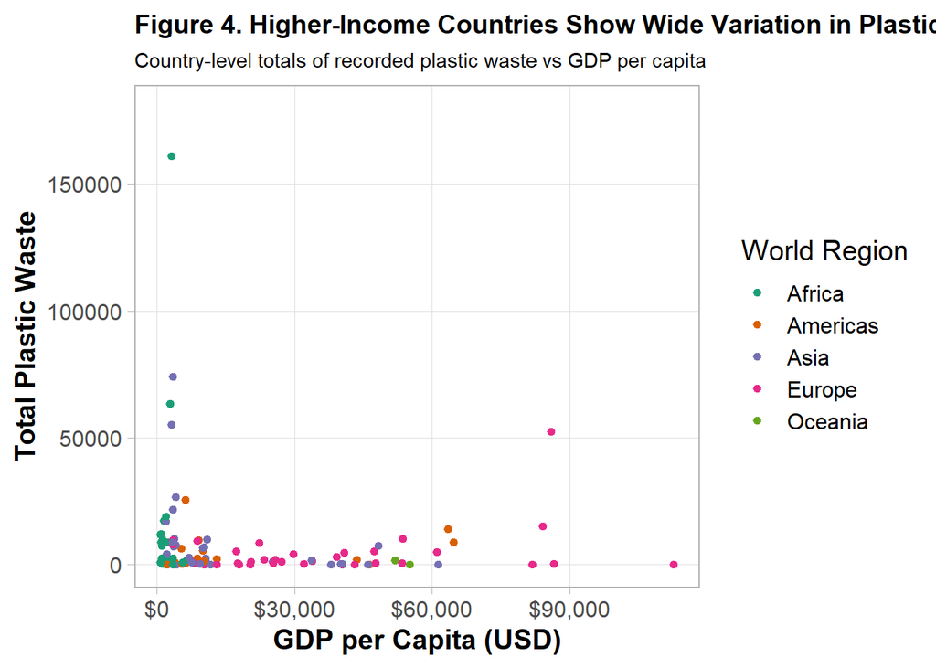

Scatterplot showing the relationship between GDP per capita and total plastic collected across countries. Points are colored by region to highlight geographic differences.

```r
vis_2 <- joined_all %>%
  filter(!is.na(region), !is.na(gdppercapita)) %>%
  group_by(country, gdppercapita, region) %>%
  summarize(
    total = sum(grand_total, na.rm = TRUE),
    .groups = "drop"
  ) %>%
  ggplot(aes(x = gdppercapita, y = total, color = region)) +
  geom_point(alpha = 1, size = 1.5) +
  scale_x_continuous(labels = label_dollar()) +
  scale_color_brewer(
    palette = "Dark2",
    name = "World Region"
  ) +
  coord_cartesian(ylim = c(0, 180000)) +
  labs(
    title = "Figure 4. Higher-Income Countries Show Wide Variation in Plastic Waste",
    subtitle = "Country-level totals of recorded plastic waste vs GDP per capita",
    x = "GDP per Capita (USD)",
    y = "Total Plastic Waste"
  ) +
  theme_light(base_size = 15) +
  theme(
    plot.title = element_text(face = "bold", size = 14),
    plot.subtitle = element_text(size = 11),
    axis.title = element_text(face = "bold"),
    panel.grid.minor = element_blank()
  )

vis_2
```

# Modeling the Effect of GDP and Region on Plastic Waste

```r
country_year <- joined_all %>%
  group_by(country, year, region) %>%
  summarise(
    total_plastic = sum(grand_total, na.rm = TRUE),
    gdp = mean(gdp, na.rm = TRUE),
    population = mean(population, na.rm = TRUE),
    .groups = "drop"
  ) %>%
  filter(
    !is.na(total_plastic),
    !is.na(gdp),
    !is.na(region)
  )

model_data <- country_year %>%
  filter(
    total_plastic > 0,
    !is.na(gdp),
   # !is.na(Temperature),
    !is.na(region)
  ) %>%
  mutate(
    log_total_plastic = log(total_plastic),
    log_gdp = log(gdp)
  )

plastic_model <- lm(
  log_total_plastic ~ log_gdp + region,
  data = model_data
)

summary(plastic_model)
```

```
Call:
lm(formula = log_total_plastic ~ log_gdp + region, data = model_data)

Residuals:
    Min      1Q  Median      3Q     Max
-7.0592 -1.2700  0.5584  1.7262  4.1387

Coefficients:
               Estimate Std. Error t value Pr(>|t|)
(Intercept)      1.6093     3.5386   0.455   0.6503
log_gdp          0.2684     0.1409   1.905   0.0597 .
regionAmericas  -1.7675     0.8813  -2.006   0.0476 *
regionAsia      -1.6887     0.7836  -2.155   0.0336 *
regionEurope    -2.1074     0.7424  -2.839   0.0055 **
regionOceania   -4.5022     1.9289  -2.334   0.0216 *
---
Signif. codes:  0 '***' 0.001 '**' 0.01 '*' 0.05 '.' 0.1 ' ' 1

Residual standard error: 2.531 on 99 degrees of freedom
Multiple R-squared:  0.1026,    Adjusted R-squared:  0.05724
F-statistic: 2.263 on 5 and 99 DF,  p-value: 0.05394
```

**Model Table**

```r
library(broom)
library(gt)

model_table <- tidy(plastic_model, conf.int = TRUE) %>%
  dplyr::select(term, estimate, std.error, statistic, p.value, conf.low, conf.high)

model_gt <- model_table %>%
  gt() %>%
  cols_label(
    term = md("**Term**"),
    estimate = md("**Estimate**"),
    std.error = md("**Std. Error**"),
    statistic = md("**t Statistic**"),
    p.value = md("**p-value**"),
    conf.low = md("**CI Lower**"),
    conf.high = md("**CI Upper**")
  ) %>%
  fmt_number(
    columns = c(estimate, std.error, statistic, conf.low, conf.high),
    decimals = 3
  ) %>%
  fmt_number(
    columns = p.value,
    decimals = 4
  ) %>%
  tab_header(
    title = md("**Regression Model for Log Total Plastic**")
  ) %>%
  tab_source_note(
    source_note = "Linear regression model predicting log total plastic from GDP and region."
  )

model_gt
```

**Regression Model for Log Total Plastic**

| **Term** | **Estimate** | **Std. Error** | **t Statistic** | **p-value** | **CI Lower** | **CI Upper** |
| --- | --- | --- | --- | --- | --- | --- |
| (Intercept) | 1.609 | 3.539 | 0.455 | 0.6503 | −5.412 | 8.631 |
| log_gdp | 0.268 | 0.141 | 1.905 | 0.0597 | −0.011 | 0.548 |
| regionAmericas | −1.767 | 0.881 | −2.006 | 0.0476 | −3.516 | −0.019 |
| regionAsia | −1.689 | 0.784 | −2.155 | 0.0336 | −3.244 | −0.134 |
| regionEurope | −2.107 | 0.742 | −2.839 | 0.0055 | −3.580 | −0.634 |
| regionOceania | −4.502 | 1.929 | −2.334 | 0.0216 | −8.330 | −0.675 |

Linear regression model predicting log total plastic from GDP and region.

Regional effects show clearer patterns. Compared to the reference region (Africa), countries in the Americas (β = −1.767, p = 0.0476), Asia (β = −1.689, p = 0.0336), Europe (β = −2.107, p = 0.0055), and Oceania (β = −4.502, p = 0.0216) all have significantly lower levels of plastic waste, holding GDP constant. These results suggest that geographic differences play an important role in plastic waste patterns, potentially reflecting differences in waste management systems, consumption behaviors, or environmental policies.

Overall, the model provides evidence that regional factors are more strongly associated with plastic waste than economic activity, while GDP shows a weaker but suggestive relationship. This addresses our research question by indicating that both economic and geographic context contribute to variation in plastic waste across countries, with region emerging as an important factor.